# Practical Machine Learing Project

Raylight

Saturday, October 25, 2014

In this project, the participants were asked to perform one set of 10 repetitions of the Unilateral Dumbbell Biceps Curl in five different fashions according to certain specification Class A, Class B, Class C, Class D and Class E. Class A represents the specific execution of the exercise, while other classes represent the common mistakes. The data for this project come from this source: http://groupware.les.inf.puc-rio.br/har. The data was collected from accelerometers on the belt, forearm, arm, and dumbell of six participants.We are interested to predict how the Class ‘classe variable’ depends on the other variables.In order to predict, first data in “pml-training.cvs”was divided into training and testing data set. The two models were developed based on regression tree and random forests using training data set. The accuracy of models were cross-validated with testing data set, which shows that the random forests model was fitted better than regression tree and could predict the dependency of classe variable on the other variables with high accuracy.

```r
library(knitr)
library(caret)
library(Hmisc)
library(gridExtra)
library(rpart)
library(rpart.plot)
library(rattle)
library(randomForest)
```

DATA READING AND CLEANING

Read the training and testing files:

```r
read_trainingData <- read.csv("pml-training.csv")
read_validatingData <- read.csv("pml-testing.csv")
```

Filtering training set:

1).Compare the variables in both training and testing data set provided in .csv files.

2).Remove those variables from training data set, which contain missing and empty observations in testing data set.

3).Save filtered training data set as sub_read_trainingData

```r
head(read_trainingData)
head(read_validatingData)
names <- colnames(read_trainingData)
kurtosis_str <- grep("kurtosis_", colnames(read_trainingData))
skewness_str <- grep("skewness_", colnames(read_trainingData))
max_str <- grep("max_", colnames(read_trainingData))
min_str <- grep("min_", colnames(read_trainingData))
amplitude_str <- grep("amplitude_", colnames(read_trainingData))
avg_str <- grep("avg_", colnames(read_trainingData))
stddev_str <- grep("stddev_", colnames(read_trainingData))
var_str <- grep("var_", colnames(read_trainingData))
sub_read_trainingData <- subset(read_trainingData,select=-c(kurtosis_str,skewness_str,max_str,min_str,amplitude_str,avg_str,stddev_str,var_str))
str(sub_read_trainingData)
```

Remove first seven columns from training data set since we are interested to predict classe with belt,forearm,arm and dumbell only:

```r
sel_sub_read_trainingData <- sub_read_trainingData[,8:60]
str(sel_sub_read_trainingData)
head(sel_sub_read_trainingData)
```

Remove NA values:

```r
omit_sel_sub_read_trainingData <- na.omit(sel_sub_read_trainingData)
str(omit_sel_sub_read_trainingData)
```

Creating training and testing sets for cross validation:

```r
inTrain <-createDataPartition(omit_sel_sub_read_trainingData$classe,p=0.7,list=FALSE)
fil_training <- omit_sel_sub_read_trainingData[inTrain,]
fil_testing <- omit_sel_sub_read_trainingData[-inTrain,]
```

Some plots to explore

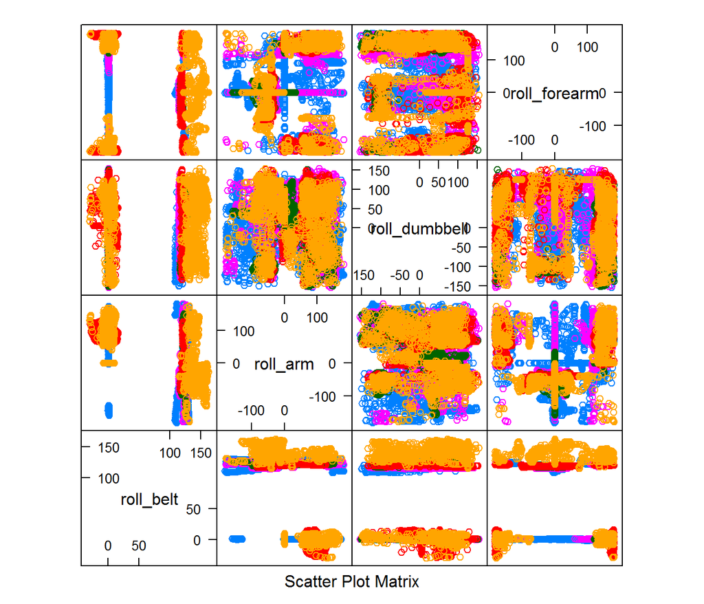

```r
featurePlot(x=fil_training[,c("roll_belt","roll_arm","roll_dumbbell","roll_forearm")],y=fil_training$classe,plot="pairs")
```

```r
# See Figure 1
```

```r
p1 <- qplot(roll_belt,roll_arm,colour=classe,data=fil_training)
p2 <- qplot(roll_dumbbell,roll_forearm,colour=classe,data=fil_training)
grid.arrange(p1,p2,ncol=2)
p3 <- qplot(total_accel_belt,total_accel_arm,colour=classe,data=fil_training)
p4<- qplot(total_accel_dumbbell,total_accel_forearm,colour=classe,data=fil_training)
grid.arrange(p3,p4,ncol=2)
```

[output not shown]

FITTING MODELS TO TRAINING DATA SET

1). First, tree model is fitted to fil_training data set then the model was evaluated using fil_testing data set.

2). Second, random forest is fitted to fil_training data set then the model was evaluated using fil_testing data set.

1). Fit a tree to training data set:

```r
set.seed(10000)  # For reproducibility
# t_modFit <-train(classe~.,method="rpart",data=fil_training)    #too slow to work with large data set
t_modFit <-rpart(classe~., data=fil_training)
```

i).Plots of tree

```r
plot(t_modFit)
text(t_modFit,use.n=TRUE,all=TRUE, cex=0.6)
# See Figure 2
```

[output not shown]

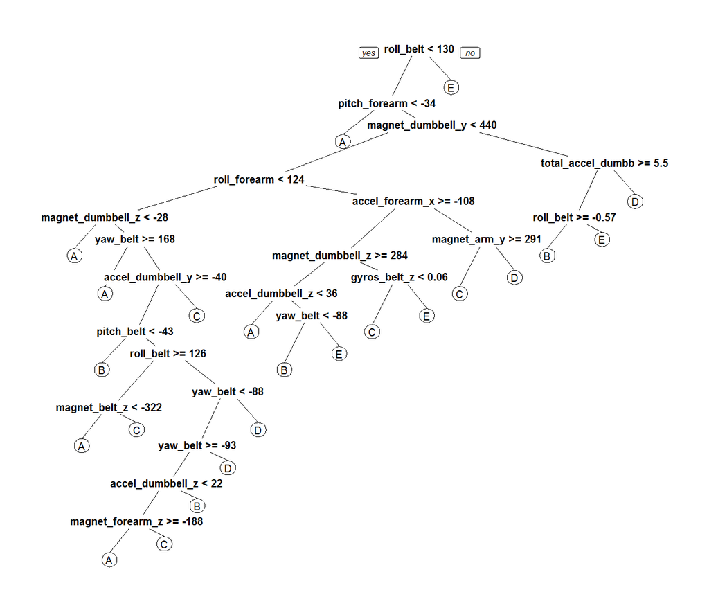

```r
prp(t_modFit)
```

```r
#fancyRpartPlot(t_modFit,cex=0.5)
```

ii).Re-substitution error

```r
table(fil_training$classe, predict(t_modFit, type="class"))
```

[output not shown]

iii).Predicting with test data set

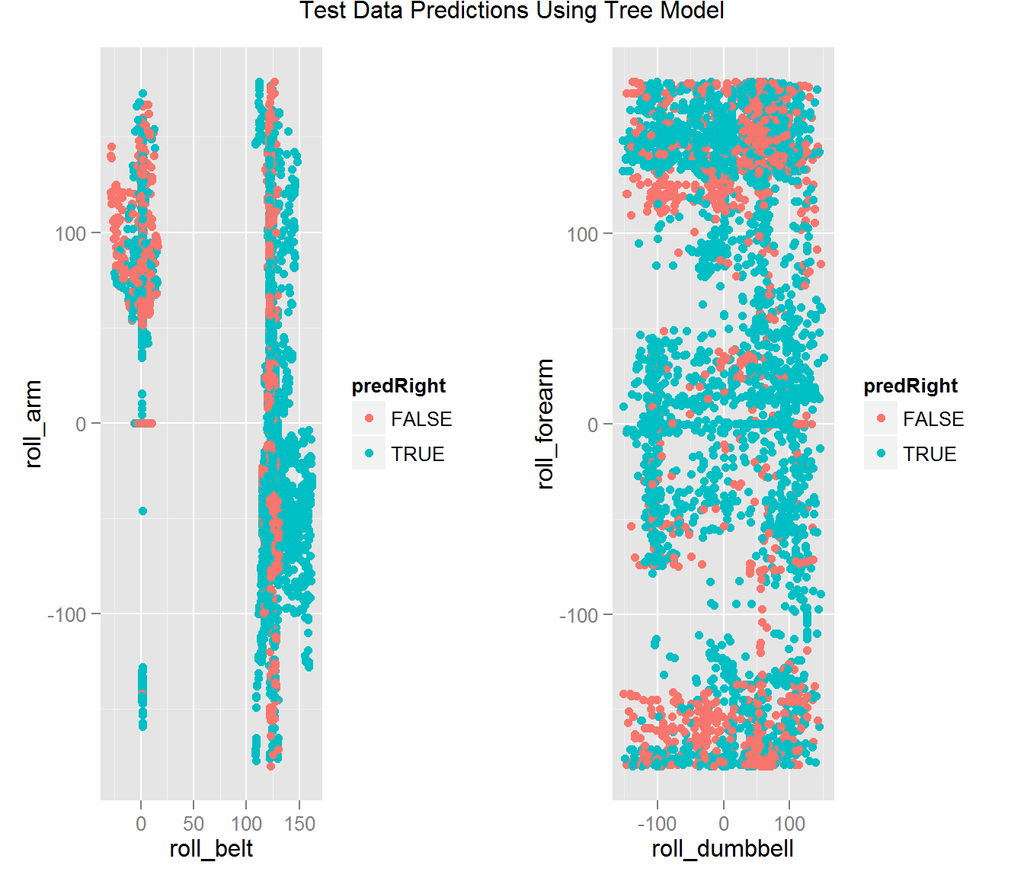

```r
tree.pred <- predict(t_modFit,fil_testing,type="class")
fil_testing$predRight <- tree.pred==fil_testing$classe
p1t <- qplot(roll_belt,roll_arm,colour=predRight,data=fil_testing)
p2t <- qplot(roll_dumbbell,roll_forearm,colour=predRight,data=fil_testing)
grid.arrange(p1t,p2t,ncol=2,main="Test Data Predictions Using Tree Model")
```

```r
#See Figure 3
```

iv). Cross Validation:

a).The accuracy of model on testing data set

```r
AR_t <- sum(fil_testing$classe==tree.pred)/length(tree.pred)
AR_t
```

```
## [1] 0.7439252
```

b).Out of sample error

```r
t_out_of_sample_error=1-AR_t
t_out_of_sample_error
```

```
## [1] 0.2560748
```

t_out_of_sample_error = 0.2560748

2). Fit a random forests:

```r
set.seed(10000)      # For reproducibility
#rf_modFit <-train(classe~.,method="rf",data=fil_training); too slow to work with large data set
rf_modFit <-randomForest(classe~., data=fil_training)
rf_modFit
```

[output not shown]

i).Plots of random forests

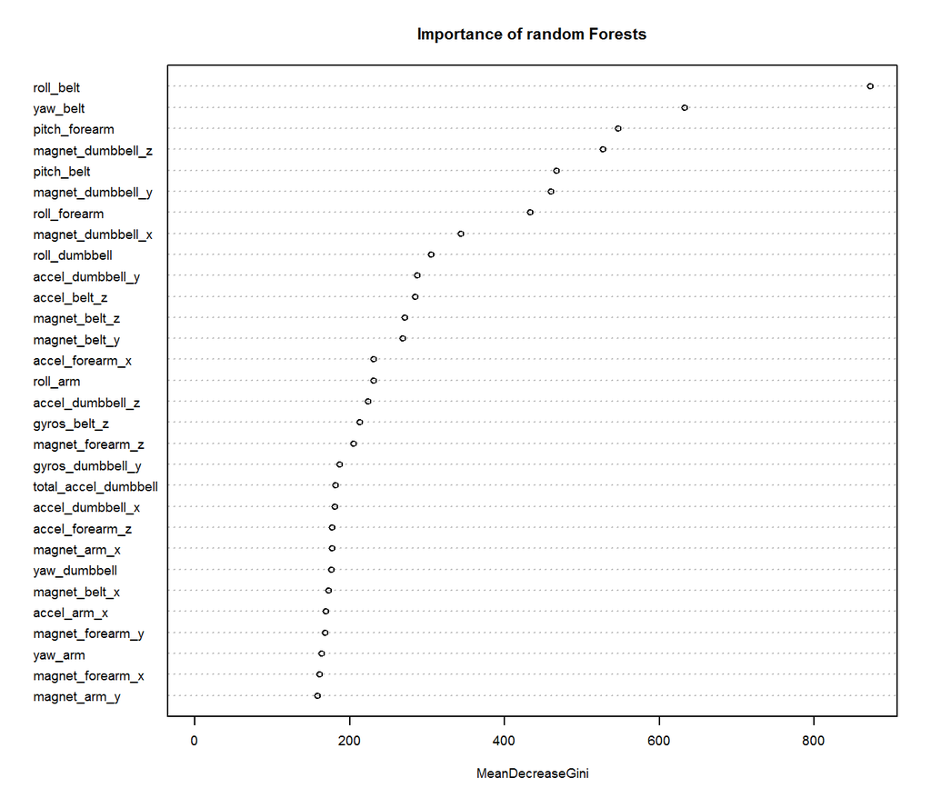

```r
varImpPlot(rf_modFit,main="Importance of random Forests", cex=.6)
```

```r
# See Figure 4
```

2. Model evaluate:importance of variables produced by random forest (Gini Index)

```r
gini <- importance(rf_modFit)
df_gini <- as.data.frame(gini)
order_gini <-gini[order(-df_gini$MeanDecreaseGini),]
```

ii).Re-substitution error

```r
table(fil_training$classe, predict(rf_modFit, type="class"))
```

[output not shown]

iii).Predicting with test data set

```r
randomForest.pred <- predict(rf_modFit,fil_testing, type="class")
```

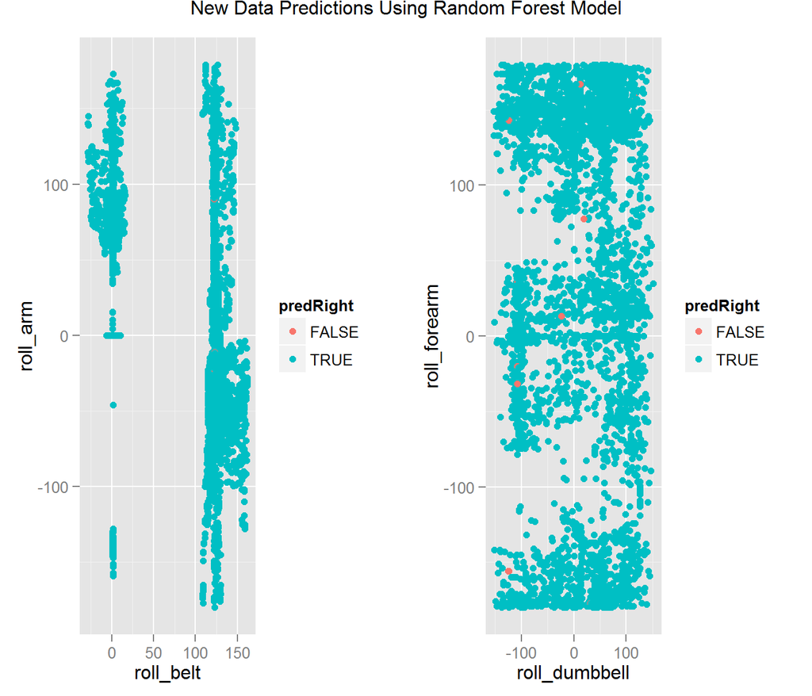

```r
fil_testing$predRight <- randomForest.pred==fil_testing$classe
p1V <- qplot(roll_belt,roll_arm,colour=predRight,data=fil_testing)
p2V <- qplot(roll_dumbbell,roll_forearm,colour=predRight,data=fil_testing)
grid.arrange(p1V,p2V,ncol=2,main="New Data Predictions Using Random Forest Model")
```

```r
# See Figure 5
```

Confusion Matrix

```r
rf_CM <- confusionMatrix(fil_testing$classe,predict(rf_modFit,fil_testing))
```

iv). Cross Validation: a).The accuracy of model on testing data set

```r
AR_rf <- sum(fil_testing$classe==randomForest.pred)/length(randomForest.pred)
AR_rf  # This might not required since we already got accurancy from Confusion Matrix.
```

```
## [1] 0.9972812
```

b).Out of sample error

```r
rf_out_of_sample_error=1-AR_rf
rf_out_of_sample_error
```

```
## [1] 0.002718777
```

rf_out_of_sample_error =0.00271877

The calculated out of samples errors are ~0.26 and 0.003 using regression tree and random forests models. The figures for new data predictions using random forest and regression tree models also show that random forest makes very fewer mistake than regression tree model.

VALIDATING MODEL WITH TESTING DATA in “pml-testing.cvs”

Read the testing file

```r
read_validatingData <- read.csv("pml-testing.csv")
```

Cleaning up testing data as earlier :

```r
sub_read_validatingData <- subset(read_validatingData,select=-c(kurtosis_str,skewness_str,max_str,min_str,amplitude_str,avg_str,stddev_str,var_str))
sel_sub_read_validatingData <- sub_read_validatingData[,8:60]
omit_sel_sub_read_validatingData <- na.omit(sel_sub_read_validatingData)
final_validatingdata <-omit_sel_sub_read_validatingData
answers_rf <-predict(rf_modFit,final_validatingdata)
answers_rf
```

```
##  1  2  3  4  5  6  7  8  9 10 11 12 13 14 15 16 17 18 19 20
##  B  A  B  A  A  E  D  B  A  A  B  C  B  A  E  E  A  B  B  B
## Levels: A B C D E
```

SUBMISSION

```r
pml_write_files = function(x){
    n = length(x)
    for(i in 1:n){
        filename = paste0("./Answers/problem_id_",i,".txt")
        write.table(x[i],file=filename,quote=FALSE,row.names=FALSE,col.names=FALSE)
    }
}

pml_write_files(answers_rf)
```

When 20 predications were submitted, all of the answers were passed.